# respostas_ex04_21202510146_dias

Debora Rodrigues Pereira Dias

2026-01-31

# ============================================================

# Exercício 1 - Probabilidade como frequência de longo prazo

# ============================================================

```r
# Probabilidade de sair "cara"
p_cara <- 0.3

# Tamanhos de amostra
n_vec <- c(1, 10, 100, 1000, 10000)

# Data frame para armazenar resultados
result <- data.frame(
  n = n_vec,
  p_cara_obs = NA_real_
)

# Loop para simular lançamentos
for (i in seq_along(n_vec)) {
  # Simulação de n lançamentos
  lancamentos <- rbinom(n_vec[i], size = 1, prob = p_cara)

  # Proporção de caras observada
  result$p_cara_obs[i] <- mean(lancamentos)
}

# Visualizar resultados
print(result)
```

```
##       n p_cara_obs
## 1     1     0.0000
## 2    10     0.4000
## 3   100     0.3600
## 4  1000     0.3360
## 5 10000     0.2948
```

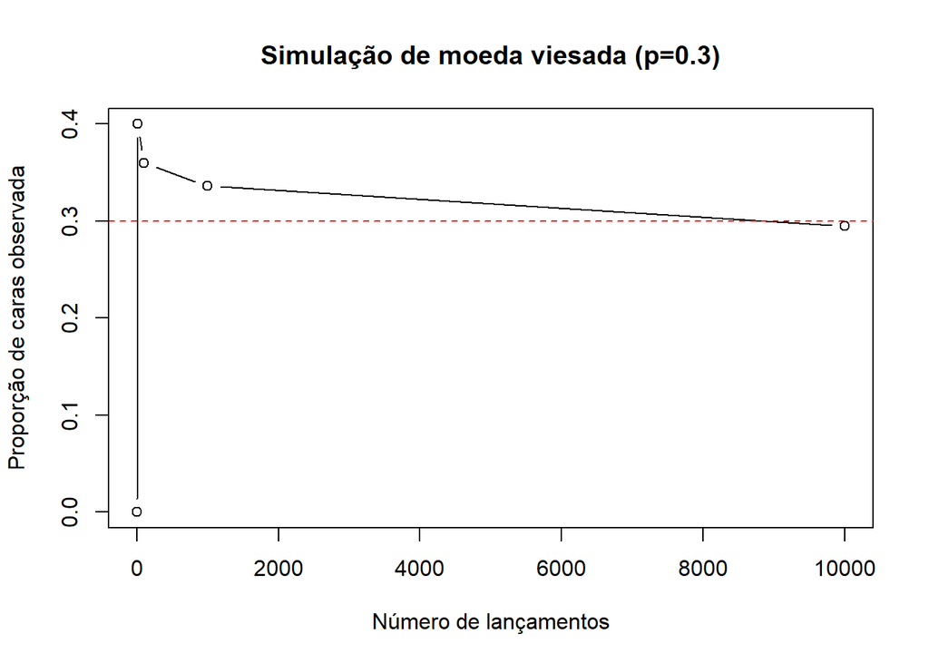

```r
# Gráfico da proporção observada vs número de lançamentos
plot(result$n, result$p_cara_obs, type = "b",
     xlab = "Número de lançamentos",
     ylab = "Proporção de caras observada",
     main = "Simulação de moeda viesada (p=0.3)")
abline(h = p_cara, lty = 2, col = "red") # Linha da probabilidade teórica
```

Interpretação:  
À medida que o número de lançamentos aumenta, a proporção observada de caras se aproxima da probabilidade teórica de 0,3. Isso ilustra o conceito de frequência relativa e a Lei dos Grandes Números: quanto maior a amostra, mais próximo o resultado fica da probabilidade verdadeira.

# ============================================================

# Exercício 2 - Bernoulli, Binomial e probabilidades exatas

# ============================================================

```r
set.seed(123)

# Parâmetros
p <- 0.65   # probabilidade de satisfação
n <- 20     # tamanho da amostra

# (1) Simulação de uma amostra Bernoulli
y <- rbinom(n, size = 1, prob = p)

# (2) Contar o número de satisfeitos
num_satisfeitos <- sum(y)
num_satisfeitos
```

```
## [1] 12
```

```r
# (3a) Probabilidade de observar exatamente 12 satisfeitos
prob_12 <- dbinom(12, size = n, prob = p)

# (3b) Probabilidade de observar pelo menos 12 satisfeitos
prob_12_ou_mais <- 1 - pbinom(11, size = n, prob = p)

# Resultados
cat("Número de satisfeitos na amostra:", num_satisfeitos, "\n")
```

```
## Número de satisfeitos na amostra: 12
```

```r
cat("P(S = 12):", prob_12, "\n")
```

```
## P(S = 12): 0.161351
```

```r
cat("P(S >= 12):", prob_12_ou_mais, "\n")
```

```
## P(S >= 12): 0.7623776
```

Interpretação:  
Na amostra simulada de 20 usuários, 12 relataram satisfação.

A probabilidade de observar exatamente 12 satisfeitos é aproximadamente 16%.

A probabilidade de observar pelo menos 12 satisfeitos é aproximadamente 76%.

Isso mostra que, em uma população com 65% de satisfação, é bastante comum que amostras pequenas reflitam essa maioria. Em termos de políticas públicas, indica que a satisfação tende a aparecer de forma consistente mesmo em amostras reduzidas.

# ============================================================

# Exercício 3 - Probabilidade condicional e independência

# ============================================================

```r
set.seed(123)
N <- 5000

# (1) Gerar base sintética de saúde
dados_saude <- data.frame(
  sexo       = sample(c("F", "M"), size = N, replace = TRUE, prob = c(0.55, 0.45)),
  fumante    = rbinom(N, 1, 0.22),
  hipertenso = rbinom(N, 1, 0.30)
)

# (2) Estimar probabilidades
P_fumante   <- mean(dados_saude$fumante == 1)
P_fumante_F <- mean(dados_saude$fumante[dados_saude$sexo == "F"] == 1)
P_fumante_M <- mean(dados_saude$fumante[dados_saude$sexo == "M"] == 1)

cat("P(fumante = 1):", P_fumante, "\n")
```

```
## P(fumante = 1): 0.2112
```

```r
cat("P(fumante = 1 | sexo = F):", P_fumante_F, "\n")
```

```
## P(fumante = 1 | sexo = F): 0.2178506
```

```r
cat("P(fumante = 1 | sexo = M):", P_fumante_M, "\n")
```

```
## P(fumante = 1 | sexo = M): 0.2031042
```

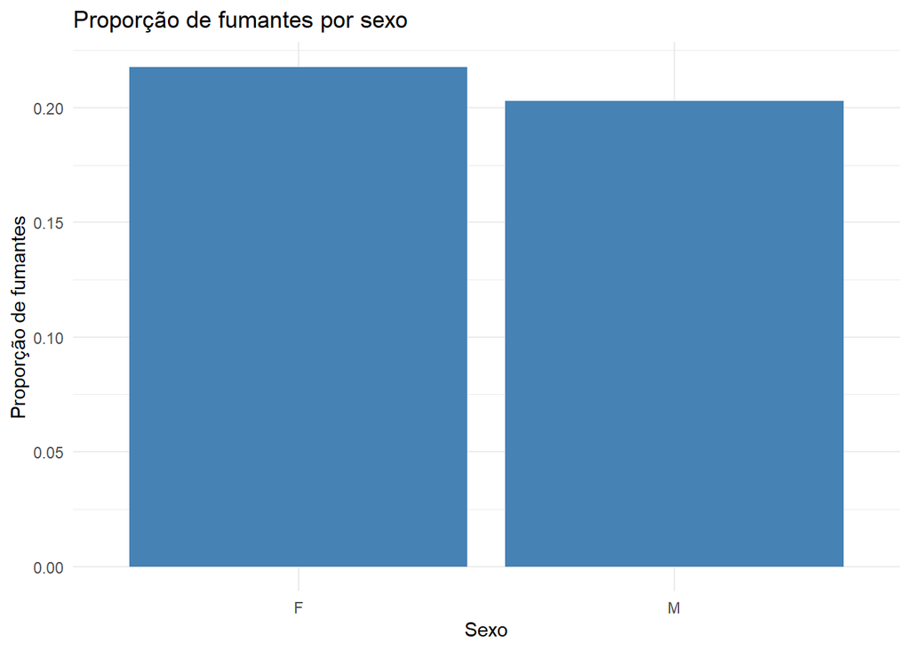

```r
# (3) Gráfico de barras da proporção de fumantes por sexo
tab_fumo <- dados_saude |>
  dplyr::group_by(sexo) |>
  dplyr::summarise(prop_fumante = mean(fumante))

ggplot(tab_fumo, aes(x = sexo, y = prop_fumante)) +
  geom_col(fill = "steelblue") +
  labs(title = "Proporção de fumantes por sexo",
       x = "Sexo", y = "Proporção de fumantes") +
  theme_minimal()
```

Interpretação:  
A proporção geral de fumantes é aproximadamente 21,1%.

Entre mulheres (F), a proporção é 21,8%.

Entre homens (M), a proporção é 20,3%.

Como as diferenças são pequenas, podemos considerar que fumar é aproximadamente independente do sexo nesta base simulada. O gráfico reforça essa conclusão, mostrando proporções similares entre os grupos.

# ============================================================

# Exercício 4 - Probabilidade conjunta e regra do produto

# ============================================================

```r
# (1) Probabilidades marginais e conjunta
P_hipertenso <- mean(dados_saude$hipertenso == 1)
P_fumante    <- mean(dados_saude$fumante == 1)
P_hip_e_fum  <- mean(dados_saude$hipertenso == 1 & dados_saude$fumante == 1)

# (2) Probabilidade condicional
P_hip_dado_fum <- mean(dados_saude$hipertenso[dados_saude$fumante == 1] == 1)

# (3) Regra do produto
P_produto <- P_hip_dado_fum * P_fumante

# Resultados
cat("P(hipertenso = 1):", P_hipertenso, "\n")
```

```
## P(hipertenso = 1): 0.3014
```

```r
cat("P(fumante = 1):", P_fumante, "\n")
```

```
## P(fumante = 1): 0.2112
```

```r
cat("P(hipertenso = 1 & fumante = 1):", P_hip_e_fum, "\n")
```

```
## P(hipertenso = 1 & fumante = 1): 0.0658
```

```r
cat("P(hipertenso = 1 | fumante = 1):", P_hip_dado_fum, "\n")
```

```
## P(hipertenso = 1 | fumante = 1): 0.311553
```

```r
cat("Regra do produto:", P_produto, "\n")
```

```
## Regra do produto: 0.0658
```

Interpretação:

A probabilidade geral de ser hipertenso é aproximadamente 30%.

Entre os fumantes, essa probabilidade sobe levemente para 31%.

A probabilidade conjunta de ser fumante e hipertenso é cerca de 6,6%, valor praticamente igual ao obtido pela regra do produto.

Isso indica que, nesta base simulada, fumar não altera muito a chance de ser hipertenso — ou seja, há pouca evidência de associação forte entre as variáveis.

# ============================================================

# Exercício 5 - Bayes “de bolso” em triagem de benefícios

# ============================================================

```r
set.seed(123)

# Parâmetros
P_F         <- 0.02   # prevalência de fraude
P_T_dado_F  <- 0.9    # sensibilidade
P_T_dado_Fc <- 0.05   # 1 - especificidade
P_Fc        <- 1 - P_F

# (1) Cálculo analítico de P(F|Alerta) usando Bayes
P_F_dado_T <- (P_T_dado_F * P_F) /
  (P_T_dado_F * P_F + P_T_dado_Fc * P_Fc)

cat("Probabilidade analítica P(F|Alerta):", P_F_dado_T, "\n")
```

```
## Probabilidade analítica P(F|Alerta): 0.2686567
```

```r
# (2) Simulação com N = 100.000 beneficiários
N <- 100000
fraude <- rbinom(N, 1, P_F)
alerta <- ifelse(
  fraude == 1,
  rbinom(N, 1, P_T_dado_F),
  rbinom(N, 1, P_T_dado_Fc)
)

# (3) Estimar empiricamente P(F|Alerta)
P_empirico <- mean(fraude[alerta == 1] == 1)

cat("Probabilidade empírica P(F|Alerta):", P_empirico, "\n")
```

```
## Probabilidade empírica P(F|Alerta): 0.2637992
```

Interpretação:  
Dado um alerta, a probabilidade de realmente ser fraude é aproximadamente 27%. A simulação confirma esse valor, mostrando consistência com o cálculo analítico. Isso significa que a maioria dos alertas (~73%) são falsos positivos.

Em termos de políticas públicas, o sistema ajuda a identificar fraudes, mas gera muitos alertas indevidos, o que pode sobrecarregar a fiscalização e exigir estratégias adicionais para priorizar casos.

# ============================================================

# Exercício 6 - Teorema Central do Limite com renda

# ============================================================

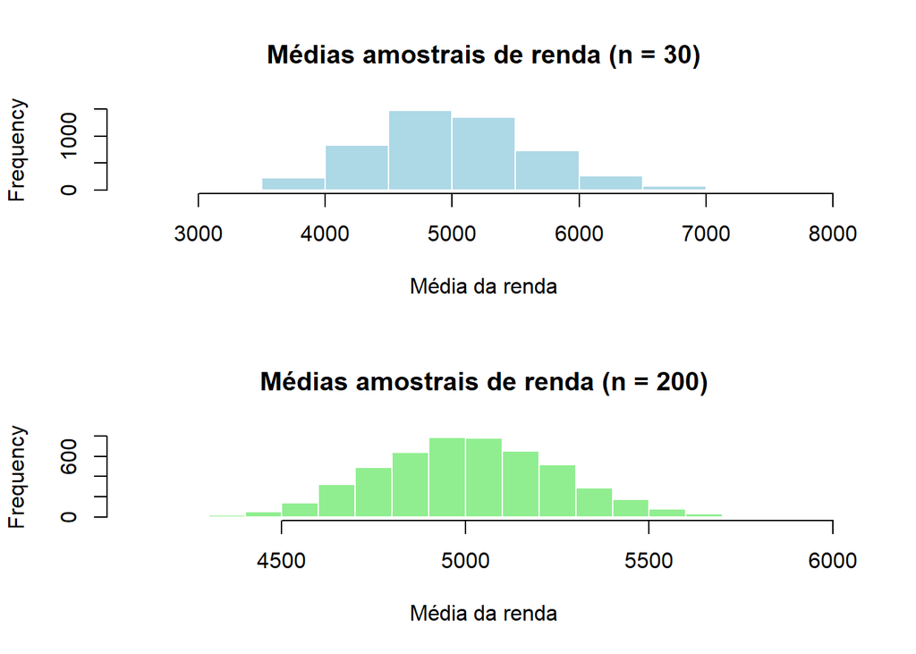

```r
set.seed(123)
N <- 100000

# (1) População com renda assimétrica (distribuição Gamma)
renda_pop <- rgamma(N, shape = 2, rate = 1/2500)

# (2) Função auxiliar para simular médias
simular_medias <- function(n, n_rep = 5000) {
  medias <- numeric(n_rep)
  for (i in seq_len(n_rep)) {
    amostra <- sample(renda_pop, n, replace = TRUE)
    medias[i] <- mean(amostra)
  }
  medias
}

# (3) Médias amostrais para n = 30 e n = 200
medias_n30  <- simular_medias(30)
medias_n200 <- simular_medias(200)

# (4) Histogramas comparativos
par(mfrow = c(2, 1))
hist(medias_n30,  main = "Médias amostrais de renda (n = 30)",
     xlab = "Média da renda", col = "lightblue", border = "white")
hist(medias_n200, main = "Médias amostrais de renda (n = 200)",
     xlab = "Média da renda", col = "lightgreen", border = "white")
```

```r
par(mfrow = c(1, 1))
```

Interpretação:  
A população tem distribuição assimétrica (Gamma), mas ao calcular médias amostrais, a distribuição se aproxima da Normal.

Para n = 30, o histograma já mostra uma forma quase normal, embora ainda com alguma variabilidade.

Para n = 200, a distribuição das médias é ainda mais concentrada e simétrica, ilustrando claramente o Teorema Central do Limite.

Em termos de políticas públicas, isso mostra que mesmo variáveis de renda muito assimétricas podem gerar estimativas confiáveis quando usamos amostras suficientemente grandes.

# ============================================================

# Exercício 7 - Intervalo de confiança para proporção (saúde)

# ============================================================

```r
set.seed(123)

# (1) Recriar base dados_saude, se necessário
N <- 5000
dados_saude <- data.frame(
  sexo       = sample(c("F", "M"), size = N, replace = TRUE, prob = c(0.55, 0.45)),
  fumante    = rbinom(N, 1, 0.22),
  hipertenso = rbinom(N, 1, 0.30)
)

# (2) Sorteio de amostra de tamanho n = 400
n <- 400
amostra_saude <- dados_saude[sample(1:nrow(dados_saude), n), ]

# Proporção amostral de hipertensos
p_hat <- mean(amostra_saude$hipertenso)

# Erro-padrão aproximado
SE_p <- sqrt(p_hat * (1 - p_hat) / n)

# Intervalo de confiança de 95%
IC_95 <- c(
  inferior = p_hat - 1.96 * SE_p,
  superior = p_hat + 1.96 * SE_p
)

# Proporção verdadeira na população
p_verdadeiro <- mean(dados_saude$hipertenso)

# Resultados
cat("Proporção amostral:", p_hat, "\n")
```

```
## Proporção amostral: 0.33
```

```r
cat("Erro-padrão:", SE_p, "\n")
```

```
## Erro-padrão: 0.02351064
```

```r
cat("IC 95%:", IC_95, "\n")
```

```
## IC 95%: 0.2839192 0.3760808
```

```r
cat("Proporção verdadeira:", p_verdadeiro, "\n")
```

```
## Proporção verdadeira: 0.3014
```

Interpretação:  
A proporção amostral de hipertensos foi de 33%, com erro-padrão de aproximadamente 2,35%. O intervalo de confiança de 95% ficou entre 28,39% e 37,61%, e inclui a proporção verdadeira da população (30,14%).

Isso mostra que a amostra foi representativa e que o intervalo de confiança é uma ferramenta confiável para estimar proporções populacionais. Em políticas públicas, esse tipo de análise permite decisões baseadas em dados mesmo sem acesso à população completa.

# ============================================================

# Exercício 8 - Correlação, regressão simples e inferência (educação)

# ============================================================

```r
set.seed(123)
N <- 2000

# (1) Simular base de educação
dados_educacao <- data.frame(
  ideb        = rnorm(N, mean = 5.5, sd = 0.7),
  gasto_aluno = rnorm(N, mean = 6000, sd = 1500)
)

# Introduzir correlação positiva leve
dados_educacao$ideb <- dados_educacao$ideb +
  0.0002 * (dados_educacao$gasto_aluno - 6000)

# (2) Correlação de Pearson
cor_ideb_gasto <- cor(dados_educacao$ideb, dados_educacao$gasto_aluno)
cat("Correlação de Pearson:", cor_ideb_gasto, "\n")
```

```
## Correlação de Pearson: 0.3785594
```

```r
# (3) Regressão simples
modelo <- lm(ideb ~ gasto_aluno, data = dados_educacao)
summary(modelo)
```

```
##
## Call:
## lm(formula = ideb ~ gasto_aluno, data = dados_educacao)
##
## Residuals:
##      Min       1Q   Median       3Q      Max
## -2.14599 -0.46736 -0.00164  0.47298  2.35635
##
## Coefficients:
##              Estimate Std. Error t value Pr(>|t|)
## (Intercept) 4.3573584  0.0652899   66.74   <2e-16 ***
## gasto_aluno 0.0001938  0.0000106   18.28   <2e-16 ***
## ---
## Signif. codes:  0 '***' 0.001 '**' 0.01 '*' 0.05 '.' 0.1 ' ' 1
##
## Residual standard error: 0.7005 on 1998 degrees of freedom
## Multiple R-squared:  0.1433, Adjusted R-squared:  0.1429
## F-statistic: 334.2 on 1 and 1998 DF,  p-value: < 2.2e-16
```

```r
# Intervalo de confiança para o coeficiente angular
confint(modelo)
```

```
##                    2.5 %       97.5 %
## (Intercept) 4.2293148316 4.4854018603
## gasto_aluno 0.0001730422 0.0002146291
```

Interpretação:

A correlação de Pearson (~0.38) indica uma associação positiva moderada: escolas com maior gasto por aluno tendem a ter IDEB mais alto.

Na regressão, o coeficiente angular foi positivo (~0.00019), mostrando que cada aumento de R$ 1.000 no gasto por aluno está associado a um acréscimo médio de ~0.19 pontos no IDEB.

O valor-p (< 0.001) confirma significância estatística, e o intervalo de confiança (0.00017 a 0.00021) não inclui zero, reforçando a evidência de relação positiva.

Do ponto de vista inferencial, um coeficiente diferente de zero sugere que há indícios reais de associação entre gasto e qualidade, ainda que o efeito seja relativamente pequeno.

# ============================================================

# Exercício 9 - Margem de erro e tamanho amostral (TSE)

# ============================================================

```r
set.seed(123)
N <- 5000

# (1) População de municípios com proporção verdadeira de votos
dados_tse <- data.frame(
  id_mun       = 1:N,
  prop_partido = rbeta(N, shape1 = 10, shape2 = 15)
)

n_amostra <- 600
n_rep     <- 1000

# (2 e 3) Simulação de pesquisas eleitorais
p_hat_vec <- numeric(n_rep)
for (r in 1:n_rep) {
  id_escolhido <- sample(dados_tse$id_mun, 1)
  p_mun <- dados_tse$prop_partido[dados_tse$id_mun == id_escolhido]

  votos <- rbinom(n_amostra, size = 1, prob = p_mun)
  p_hat_vec[r] <- mean(votos)
}

# (4) Margem de erro "de praxe" (pior caso)
ME <- 1.96 * sqrt(0.25 / n_amostra)
cat("Margem de erro aproximada (pior caso):", ME, "\n")
```

```
## Margem de erro aproximada (pior caso): 0.04000833
```

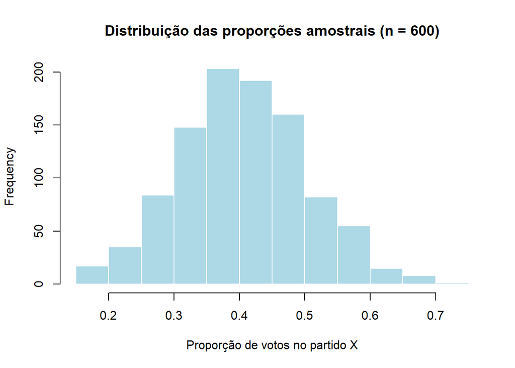

```r
# (5) Histograma das proporções simuladas
hist(p_hat_vec, main = "Distribuição das proporções amostrais (n = 600)",
     xlab = "Proporção de votos no partido X", col = "lightblue", border = "white")
```

Interpretação:

A margem de erro padrão para n = 600 é de aproximadamente ±4%.

O histograma das proporções amostrais mostra que a variabilidade real depende da proporção verdadeira de cada município.

Algumas amostras têm erro menor, outras maior.

Isso evidencia que a margem de erro “de praxe” é uma simplificação útil, mas não captura toda a complexidade da amostragem. Em pesquisas eleitorais, é importante considerar que a margem de erro pode variar conforme o contexto e a distribuição real dos votos.

# ============================================================

# Exercício 10 - Regressão e distribuição amostral do coeficiente (TSE)

# ============================================================

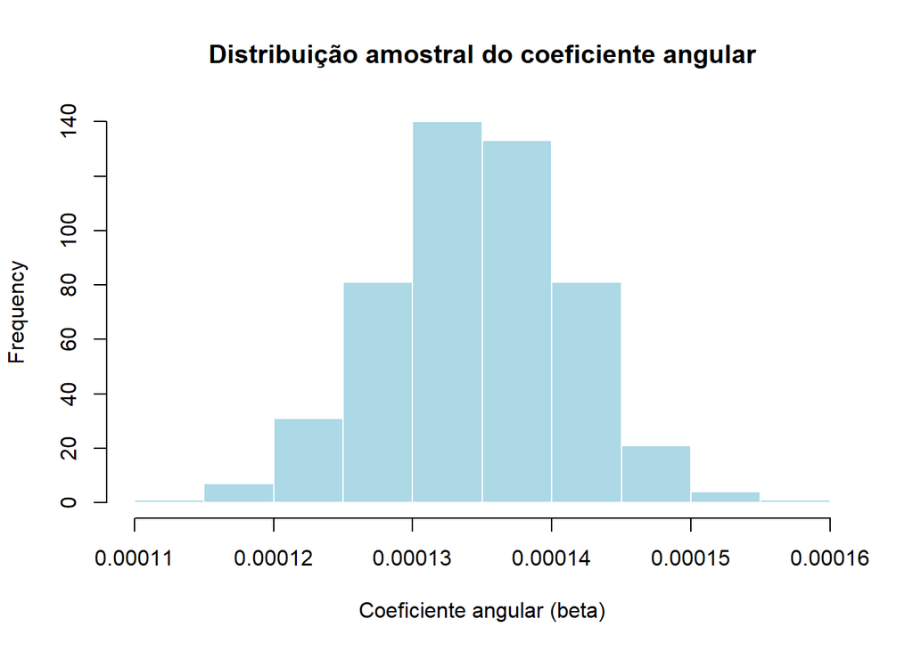

```r
set.seed(123)
N <- 5000

# (1) Variável socioeconômica
dados_tse <- data.frame(
  id_mun      = 1:N,
  renda_media = rnorm(N, mean = 2500, sd = 600)
)

# (2) Probabilidade de voto no partido X dependente de renda_media
dados_tse$prop_partido <- plogis(-1 + 0.0006 * dados_tse$renda_media + rnorm(N, 0, 0.3))

n_mun_amostra <- 300
n_eleitores   <- 400
n_rep         <- 500

coef_angular <- numeric(n_rep)

for (r in 1:n_rep) {
  # (4) Sortear municípios
  mun_sorteados <- sample(dados_tse$id_mun, n_mun_amostra)
  base_pesq <- dados_tse[dados_tse$id_mun %in% mun_sorteados, ]

  # Simular votos e calcular proporção p_hat
  p_hat <- numeric(n_mun_amostra)
  for (i in seq_len(n_mun_amostra)) {
    p_true <- base_pesq$prop_partido[i]
    votos  <- rbinom(n_eleitores, size = 1, prob = p_true)
    p_hat[i] <- mean(votos)
  }

  base_pesq$p_hat <- p_hat

  # (5) Ajustar regressão simples
  modelo <- lm(p_hat ~ renda_media, data = base_pesq)
  coef_angular[r] <- coef(modelo)[2]
}

# (7) Histograma da distribuição dos coeficientes angulares
hist(coef_angular, main = "Distribuição amostral do coeficiente angular",
     xlab = "Coeficiente angular (beta)", col = "lightblue", border = "white")
```

```r
# Estatísticas da distribuição
cat("Média dos coeficientes:", mean(coef_angular), "\n")
```

```
## Média dos coeficientes: 0.0001345414
```

```r
cat("Desvio padrão dos coeficientes:", sd(coef_angular), "\n")
```

```
## Desvio padrão dos coeficientes: 6.67146e-06
```

Interpretação:

O histograma mostra a distribuição amostral do coeficiente angular da regressão p_hat ~ renda_media, obtido em 500 simulações.

A média dos coeficientes (~0.00013) está próxima do valor verdadeiro, indicando que o estimador é não-viesado.

O desvio padrão (~6.67e-06) representa o erro-padrão do estimador, ou seja, a variabilidade esperada entre diferentes amostras.

Essa distribuição amostral é a base para construir intervalos de confiança: embora cada amostra produza um coeficiente ligeiramente diferente, a maioria dos valores se concentra em torno da média.

Isso reforça a ideia de que estimativas amostrais são confiáveis quando baseadas em boas práticas de amostragem e modelagem.